# Worked Example: D-Rex

Johan Larsson

## Probing an Unknown Dataset

Let’s say that we have data from an unknown source, containing two variables, `x` and `y`. The data has been uploaded to the course website, and you can download and read it into your workspace with the following command.

```r
library(tidyverse)

xy <- read_csv(
  "https://raw.githubusercontent.com/stat-lu/STAE04/master/data/xy.csv")
```

### Boxplot

Let’s try to explore the univariate distributions of these two variables. We begin with a boxplot.

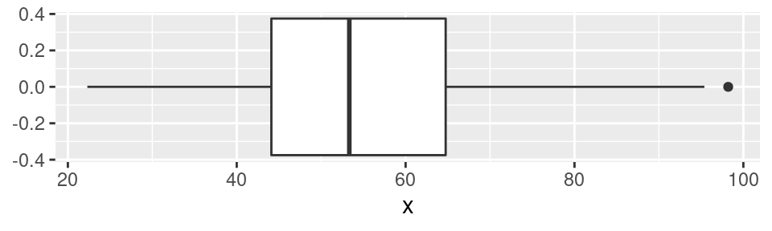

A boxplot of the x variable.

```r
ggplot(xy, aes(x)) +
  geom_boxplot()
```

As you see, our call to ggplot2 is quite simple. We use `ggplot()` with the data as the first argument and a call to `aes()` for our aesthetics specification as our second argument. The call to `aes()` is actually optional and if you want to you can provide your mappings inside the layers (geom functions) if you want to.

The distribution seems to be reasonably symmetric but with a longer tail to the right and with a single outlier at around 100. The boxplot also indicates that the distribution is uni-modal, with a center around 55. But this is the problem with boxplots: they can never “discover” anything *but* a single mode, since boxplots are based on statistics only related to the quantiles of the distribution.

### Dotplot

When studying a distribution, it is usually better to start off with a plot that does less abstraction, such as a simple dotplot. The dots in a dotplot can represent more than one observation if you want to, but I think it works best when each dot is a single observation. Use `binwidth = 1` to request this.

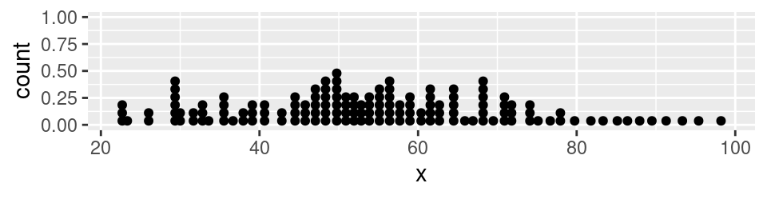

A dotplot of the x variable.

```r
ggplot(xy, aes(x)) +
  geom_dotplot(binwidth = 1)
```

It’s hard to summarize this distribution in a few words, but it does not quite seem to be uni-modal. There is also a slight indication that the values may be biased towards certain values here, which for instance is a common problem in questionnaires, where many will “round off” their answers to a whole number when they are uncertain about the answer.

### Histogram

Perhaps this is the case here, so let’s use a *histogram* instead. With histograms we need to specify the number of bins or the bindwith manually. Given the number of observations here, and the dotplot we previously plotted, a value of five might be appropriate to remove the effect of possible round-off bias and elucidate the shape of the distribution better.

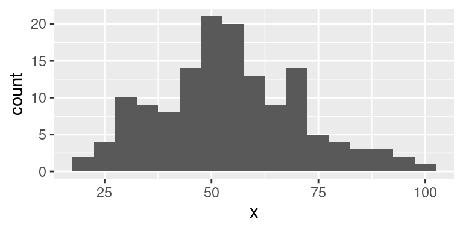

A histogram of the x variable.

```r
ggplot(xy, aes(x)) +
  geom_histogram(binwidth = 5)
```

Play around a little bit with the various settings of `bins` and/or `binwidth` to see how large the effects of these parameters can be.

### Density Plot

We could also try a density plot here. Density plots are best when you know that your data is measured on a continuous scale and can make strong assumptions about the distributions of your variables, since the choice of parameters for the density kernel have large effects on the result.

Here we try a few different choices to highlight this.

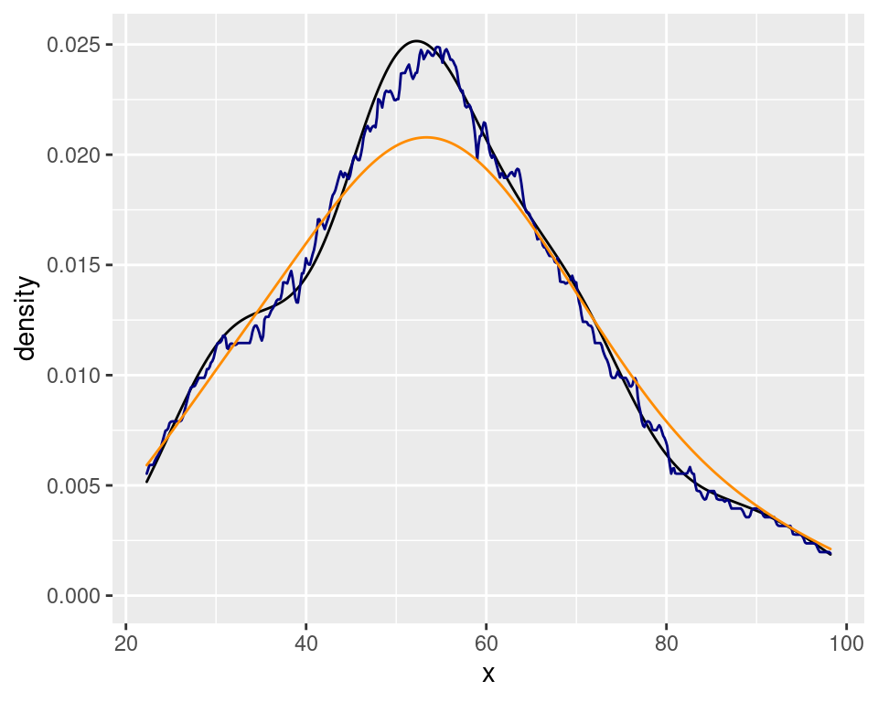

Density plots with various density estimate choices.

```r
ggplot(xy, aes(x)) +
  geom_density() + # kernel = "gaussian", the default
  geom_density(col = "navy", kernel = "rectangular") +
  geom_density(col = "dark orange", bw = 10)
```

The default density layer uses Silverman’s rule-of-thumb (see `?bw.nrd0`) for choosing bandwith but there are other choices that are probably better, such as `bw = "SJ"`.

## Multiple Distributions in One Plot

When you have several related variables from the same dataset, it often makes good sense to juxtapose them in a plot in order to make it easier for the reader to compare the distributions. We do so by first pivoting our dataset into a long format in order to have one column that denotes the name of the variable and one column that contains those variables’ values.

```r
xy_long <- pivot_longer(xy, everything())

xy_long
```

```
## # A tibble: 284 x 2
##    name  value
##    <chr> <dbl>
##  1 x      55.4
##  2 y      97.2
##  3 x      51.5
##  4 y      96.0
##  5 x      46.2
##  6 y      94.5
##  7 x      42.8
##  8 y      91.4
##  9 x      40.8
## 10 y      88.3
## # … with 274 more rows
```

We’ve used the default settings for `names_to` and `values_to` here, which gives us the column names `name` and `value` and specified that we want to pivot all the variables by calling `everything()`.

### Violin Plots

Now we’re ready to plot our distribution. Let’s try a violin plot this time.

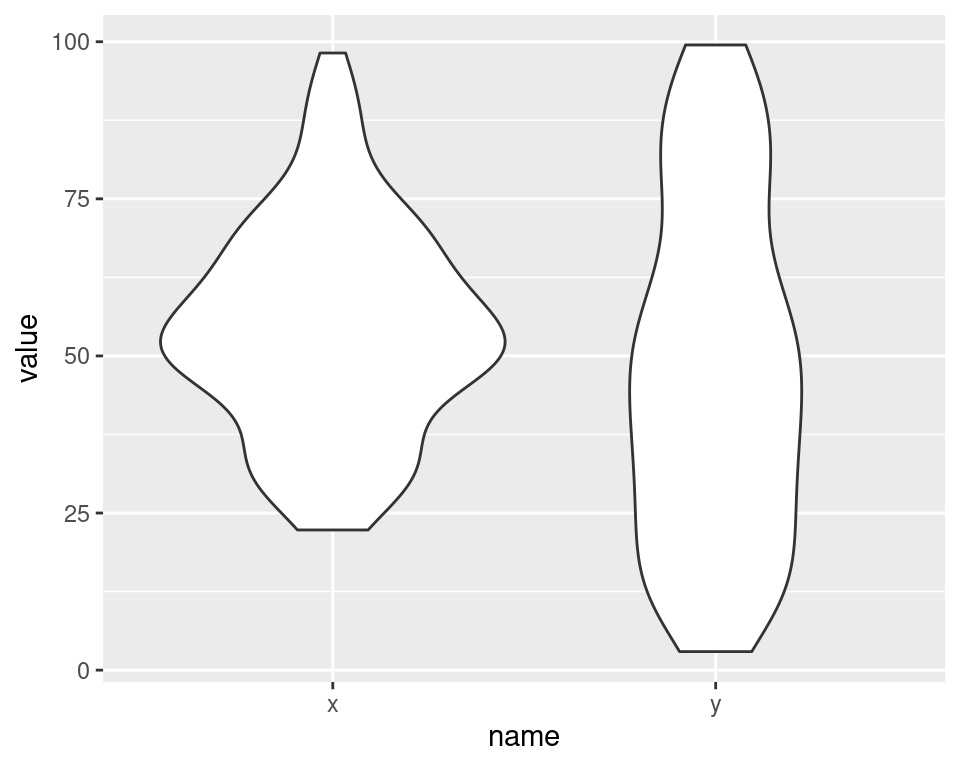

Violin plots of the x and y variables from our dataset.

```r
ggplot(xy_long, aes(name, value)) +
  geom_violin()
```

Violin plots are great for juxtaposing distributions of variables that are on roughly the same scale, which is the case here.

The distribution for `y` seems to be substantially different from that of `x`. It is definitely more flat—almost uniform.

### Faceted Histograms

Another approach, which is particularly suitable when the variables are on different scales are histograms. To plot multiple histograms we need to use *facets*. To do so, we use `facet_wrap()`.

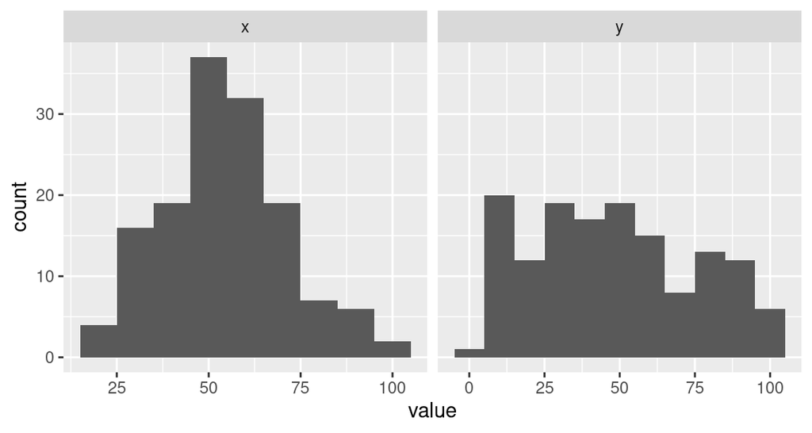

Faceted histograms of the distributions of x and y.

```r
ggplot(xy_long, aes(value)) +
    geom_histogram(binwidth = 10) +
    facet_wrap("name", scales = "free_x")
```

The argument `scaled = "free_x"` is typically appropriate when plotting multiple variables like this. Notice that we’ve used a larger bindwidth this time around.

### Patchwork

Another approach when juxtaposing plots of distributions like this is to use the patchwork package, which can be used to *patch* together plots that you have created separately. This is very useful if you want to juxtapose plots that use different types of layers. Let’s install the package first.

```r
install.packages("patchwork")
```

The idea of **patchwork** is extremely simple. You simply add separate plots together using `+`. Say we wanted to juxtapose a density plot of variable `x` with a histogram of variably `y`—all we then need to do is create the plots separately and then add them together.

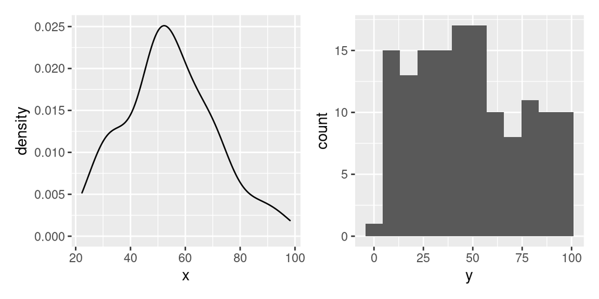

Density plot of x and histogram of y.

```r
library(patchwork)

p1 <- ggplot(xy, aes(x)) +
  geom_density(bw = "SJ")

p2 <- ggplot(xy, aes(y)) +
  geom_histogram(bins = 12)

p1 + p2
```

Simple, right? How plots are patched together can be controlled in detail, so make sure to check out the [documentation](https://patchwork.data-imaginist.com/index.html) if you’re interested.

## Rawr!

We’ve now plotted several types of plots of the distributions of this dataset and might well feel comfortable about making a few conclusions about the data. Stopping here, however, would unfortunately be a severe mistake. Because what we’ve missed is to plot the *joint* distribution of these variables, which is very easy to do using a scatter plot (which we will tackle in much more detail during the next part of the course).

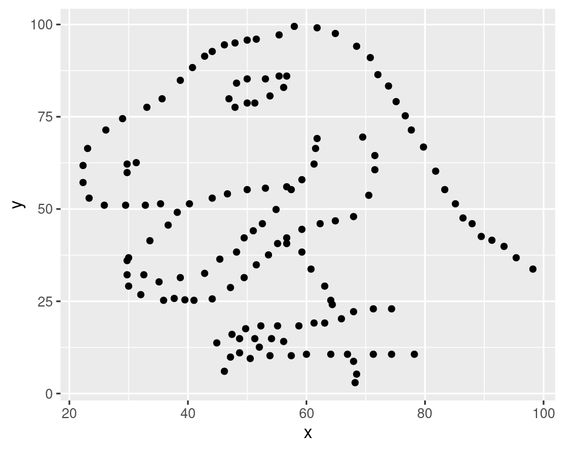

The terrifying Datasaurus Rex.

```r
ggplot(xy, aes(x, y)) +
  geom_point()
```

What is the take-home message here? Well, it’s twofold:

1. When you visualize distributions of several variables one by one, you are projecting these distributions from a multivariate space to a univariate space. In so doing, you are effectively ignoring all of the ways by which these two variables are related to one another. To be fair, it isn’t always easy (or even possible) to visualize many variables at once, but in this case we would have been far better off if we had considered a scatter plot right away.
2. Knowing your data is critical. You should never throw yourself into a dataset without at least a bit of understanding about what the variables represent and preferably also how they were collected. Make it a habit to read up on the dataset *before* you start visualizing it. For most of the data that we’ll tackle in this course, there is often documentation that you can access by looking at the help file for the dataset.

## Source Code

The source code for this document is available at https://github.com/stat-lu/STAE04/blob/master/worked-example-drex.Rmd.